Lake Name: Saratoga Lake

Lake acreage: 3770.3

County: SARATOGA

PWLID: 1101-0012

Waterbody Classification: A

Coordinates: 42.989595,-73.744366

Is this waterbody a public water supply: No

Are there DOH desingated beaches on this waterbody: Yes

Open Water Indicators

2018 Sampling Results

Seasonal Change

06-12

06-28

07-09

07-24

08-16

08-21

09-06

09-14

09-16

Clarity (m)

5.15

5.25

5.00

3.65

2.65

2.25

3.65

2.90

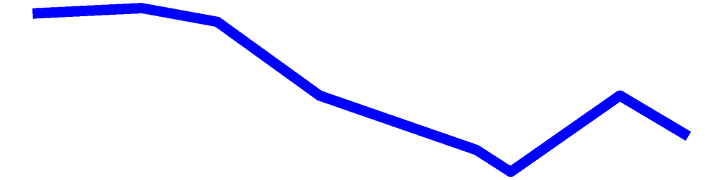

Surface TP (mg/L)

0.01

0.01

0.01

0.01

0.02

0.02

0.02

0.03

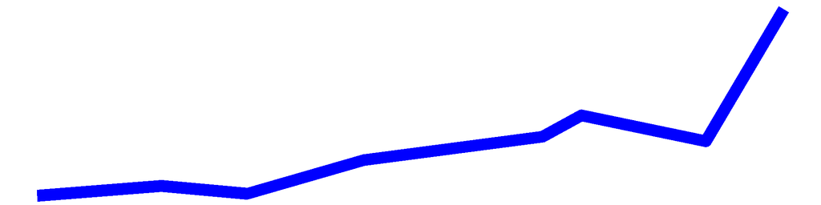

Surface TDP (mg/L)

0.00

0.00

0.00

0.00

0.00

0.00

0.00

0.00

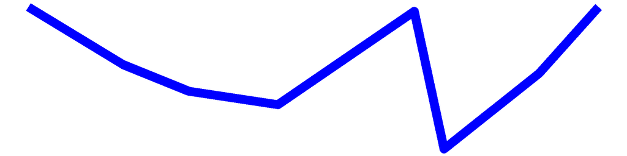

Deep TP (mg/L)

0.04

0.21

0.32

0.34

0.64

0.93

0.94

1.19

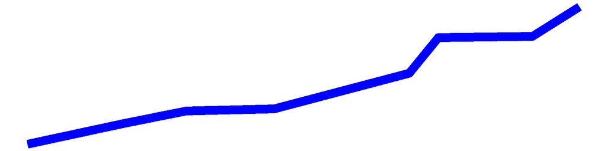

Deep TDP (mg/L)

0.01

0.10

0.00

0.02

0.04

0.05

0.15

0.13

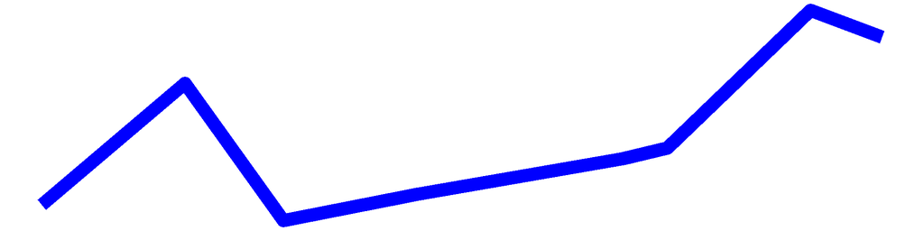

TN (mg/L)

0.48

0.18

0.50

0.28

0.24

0.33

0.44

0.28

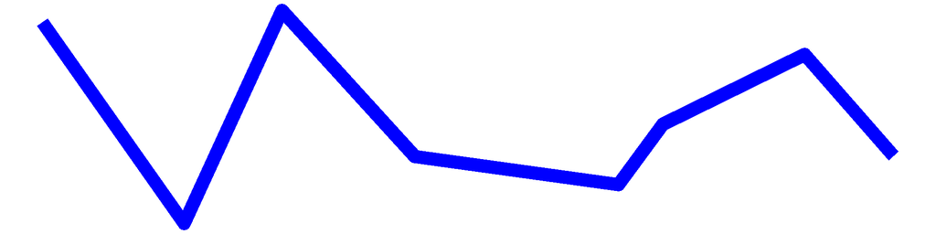

TDN (mg/L)

0.47

0.19

0.52

0.27

0.22

0.29

0.46

0.25

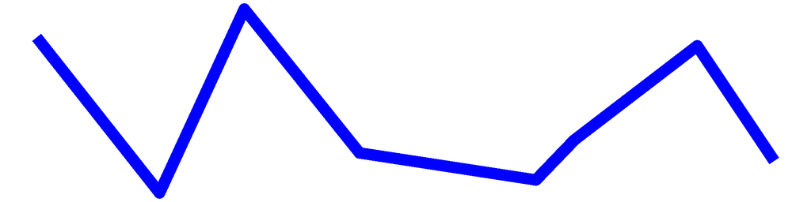

TN:TP

47.52

16.22

48.24

19.95

14.35

17.27

26.77

9.14

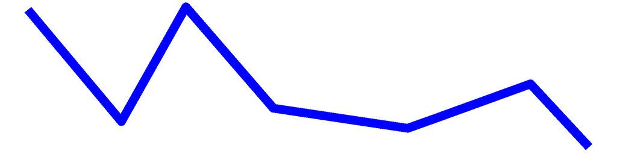

Surface NH3 (mg/L)

0.07

0.03

0.04

0.05

0.00

0.01

0.01

0.02

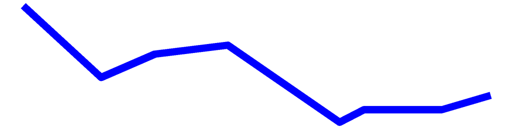

Deep NH3 (mg/L)

0.38

0.41

0.63

0.62

1.17

1.46

1.78

2.37

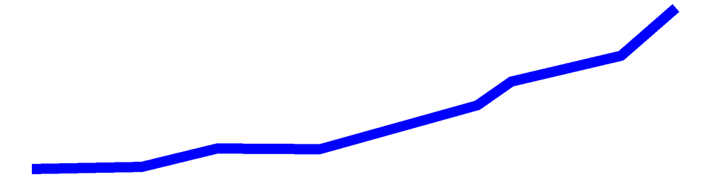

Chl.a (ug/L)

3.60

1.80

2.20

6.20

6.50

8.80

5.00

7.80

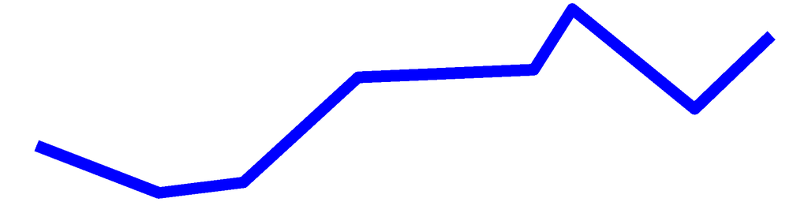

pH

7.63

8.22

7.62

7.67

7.66

7.72

7.14

7.80

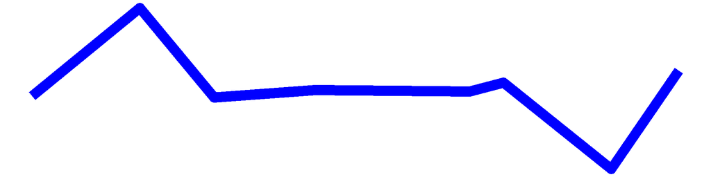

Cond (umho/cm)

424.80

477.10

462.20

318.90

330.80

456.80

449.30

423.70

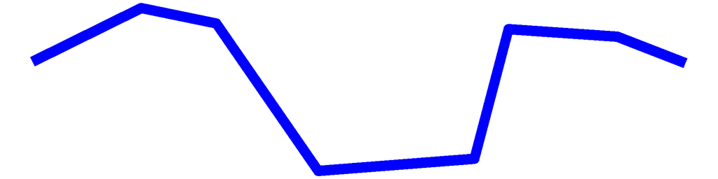

Surface Calcium (mg/L)

Bottom Calcium (mg/L)

Surface Chloride (mg/L)

68.20

62.70

Bottom Chloride (mg/L)

Upper Temp (degC)

22.00

27.60

26.80

25.80

26.00

25.20

26.00

22.90

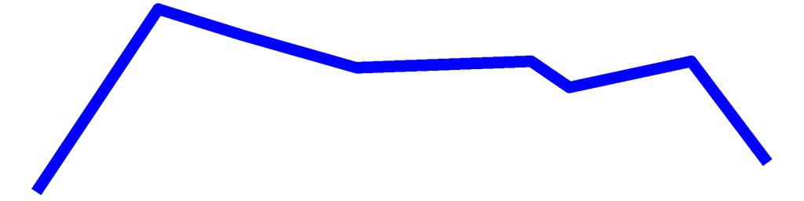

Deep Temp (degC)

12.00

12.10

12.60

13.50

14.00

14.20

15.00

14.30

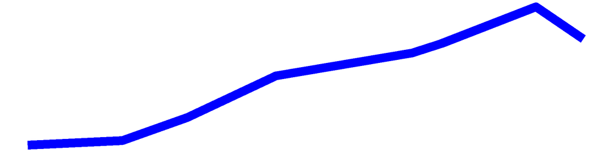

FP BG Chl.a (ug/L)

3.92

1.81

4.41

5.39

6.21

5.29

8.31

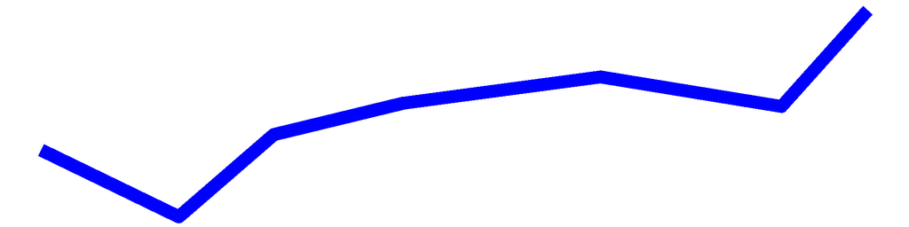

## Saratoga Lake – Sampling Season Results

### HABs Status

#### Open Water Algae

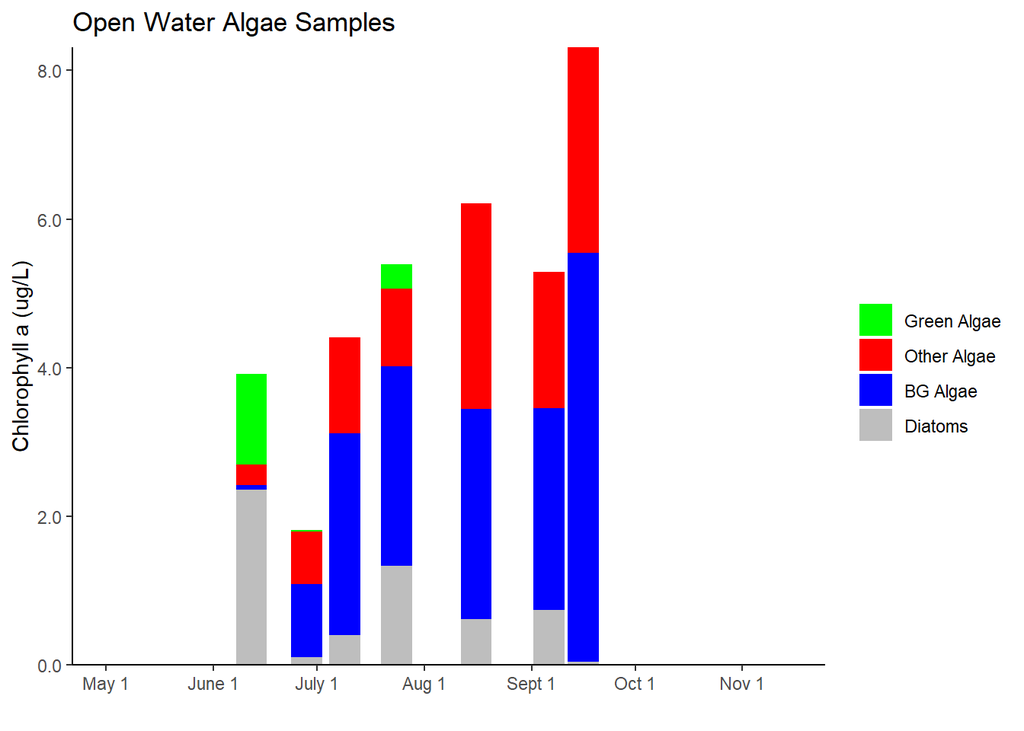

#### Shoreline Algae

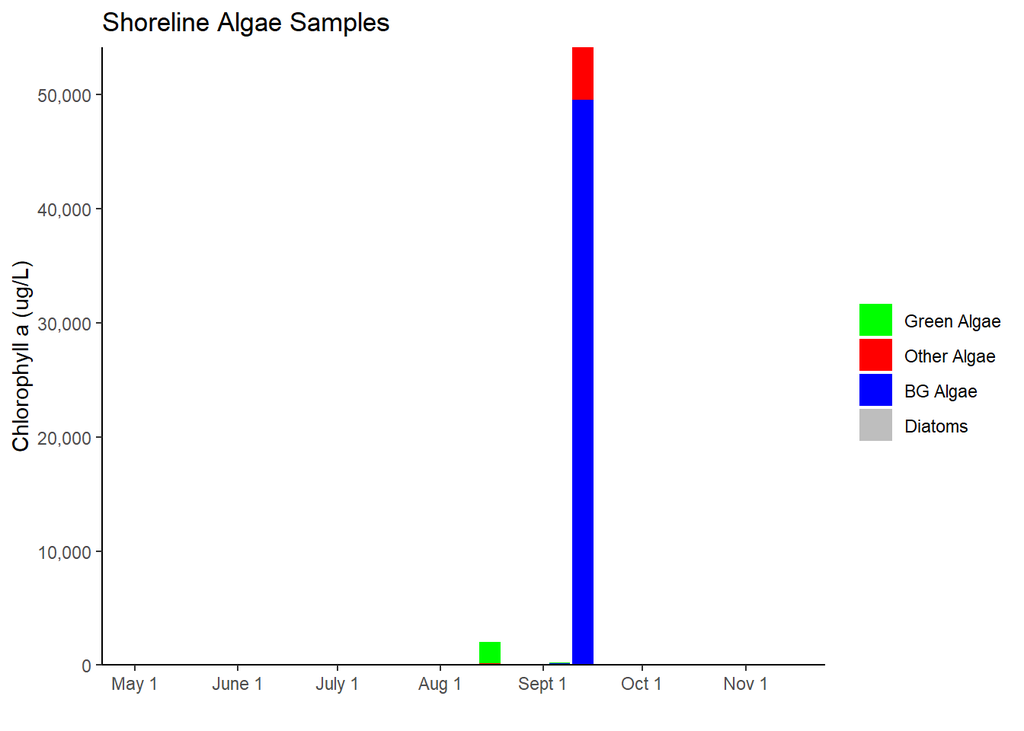

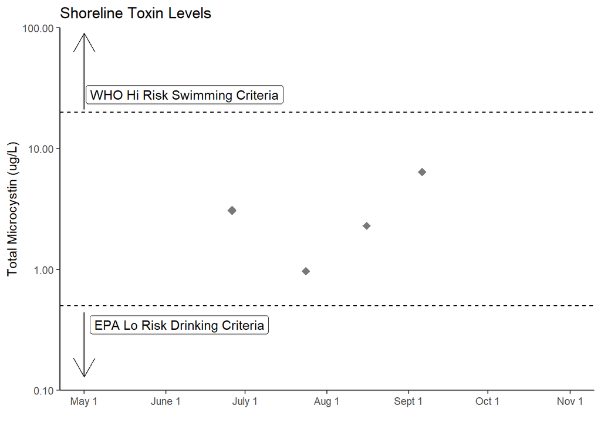

## Saratoga Lake Long-Term Trend Analysis

#### Clarity

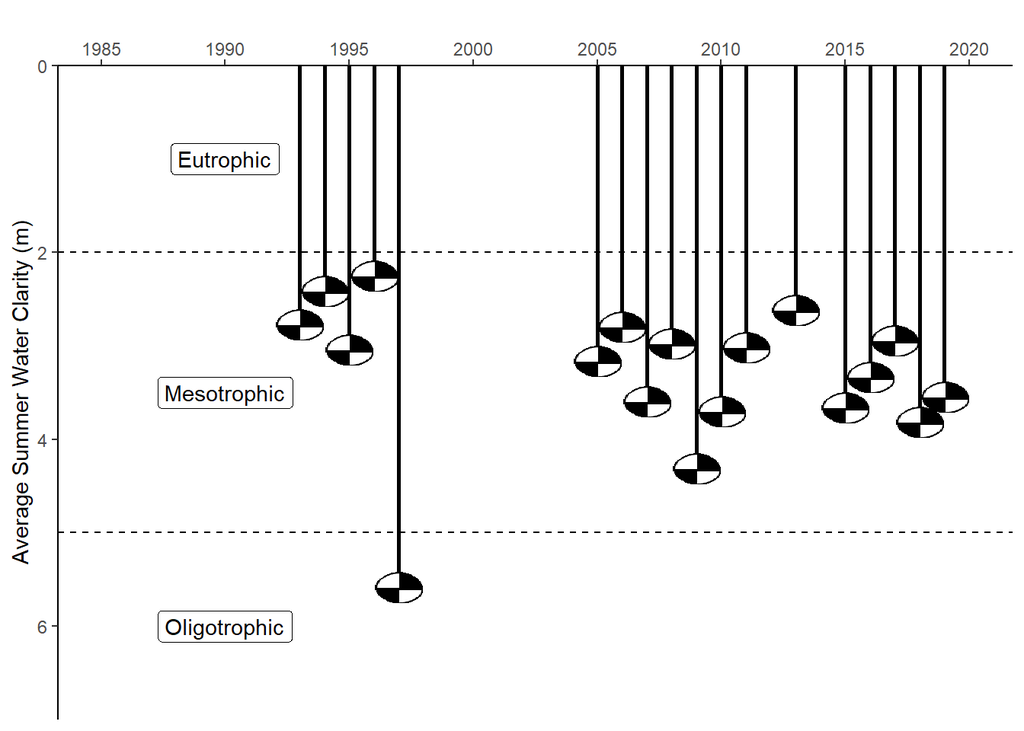

#### Chlorophyll *a*

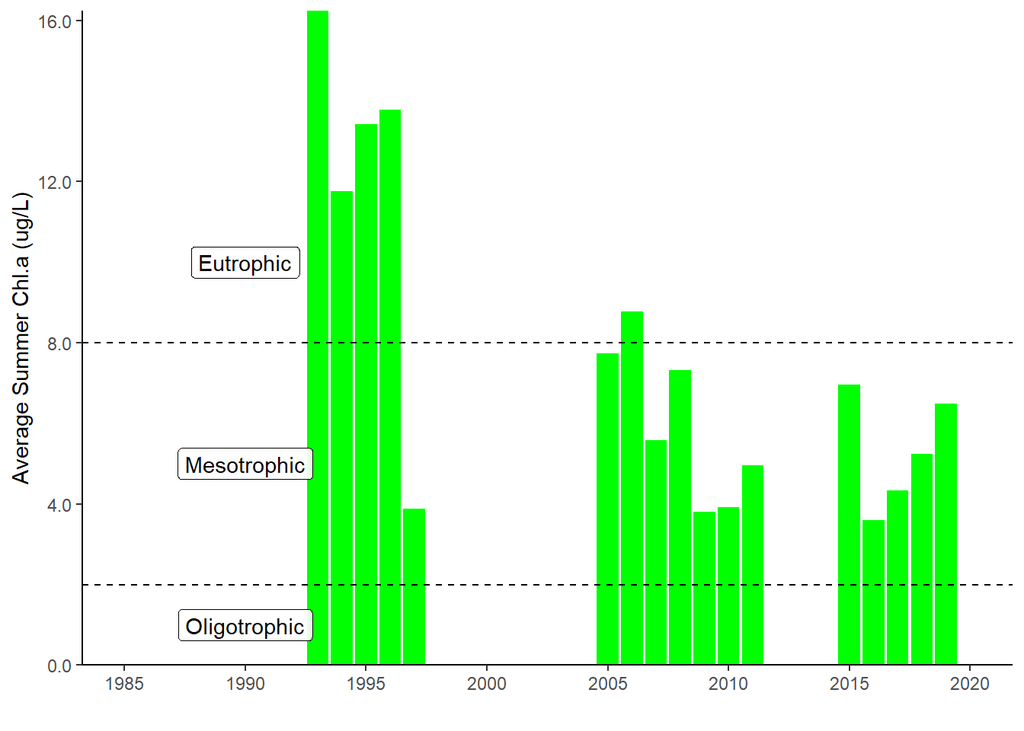

#### Surface and Deep Phosphorus

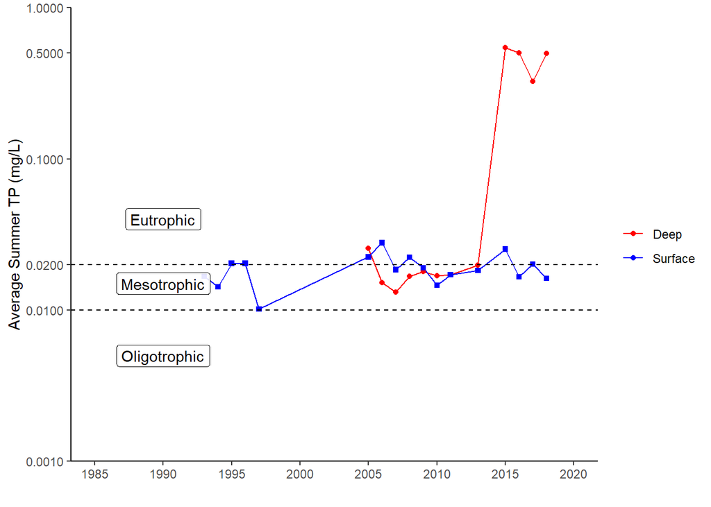

#### Nitrogen

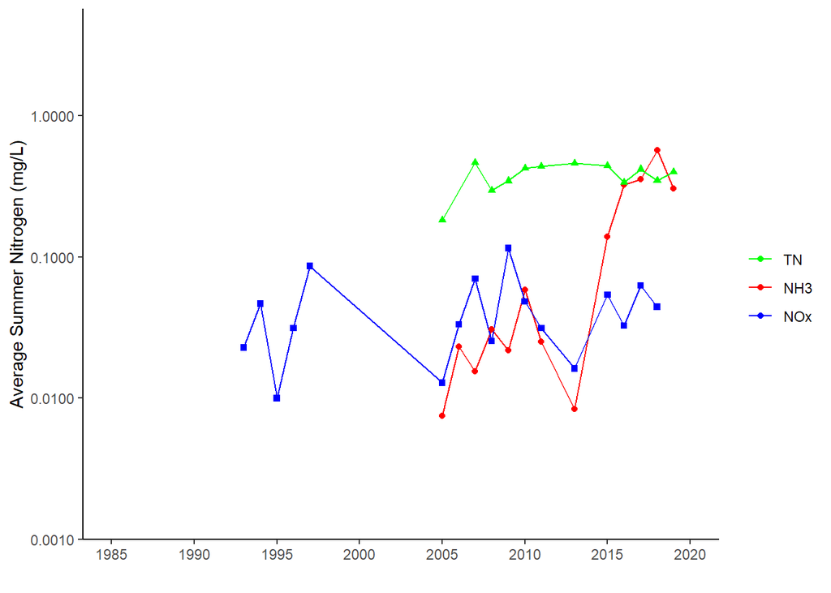

#### TN : TP

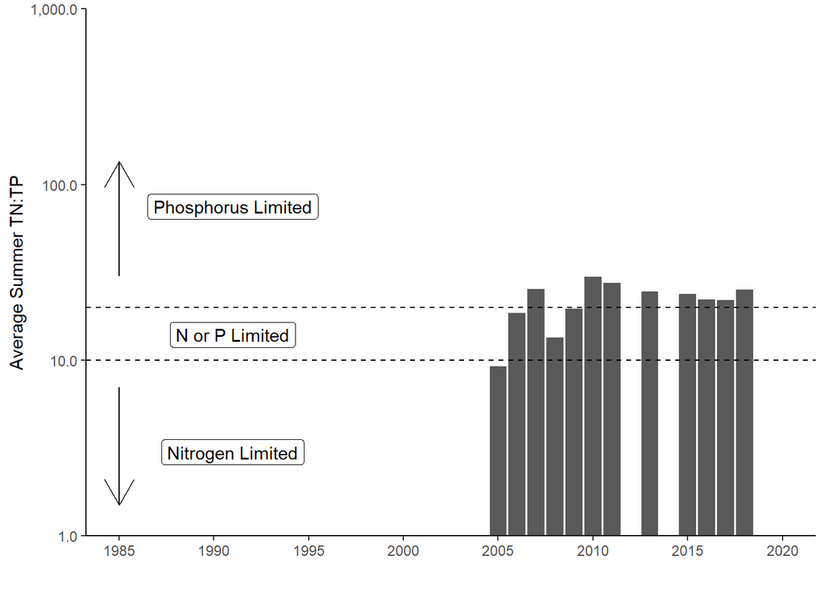

#### pH

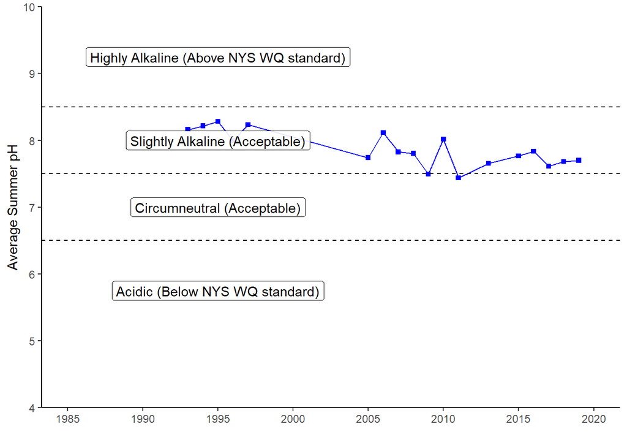

#### Specific Conductance

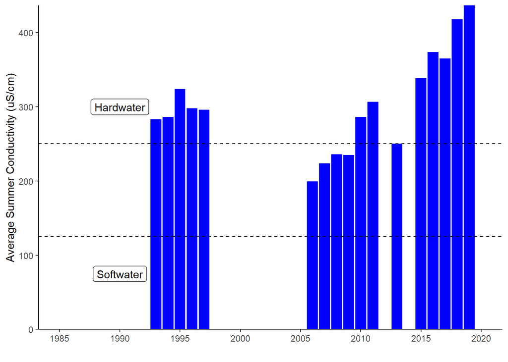

#### Calcium

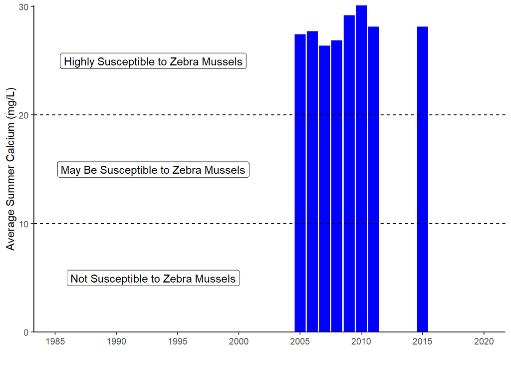

#### Chloride

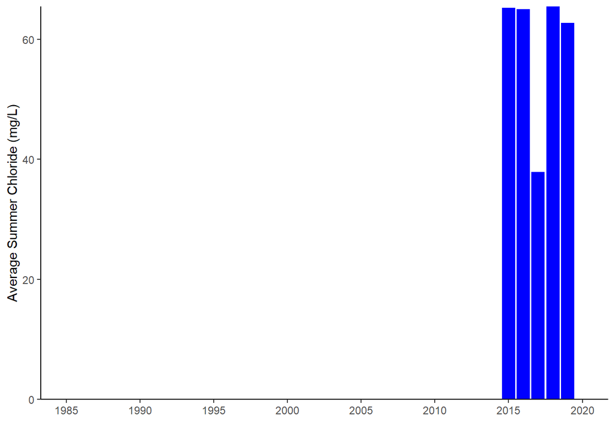

#### Color

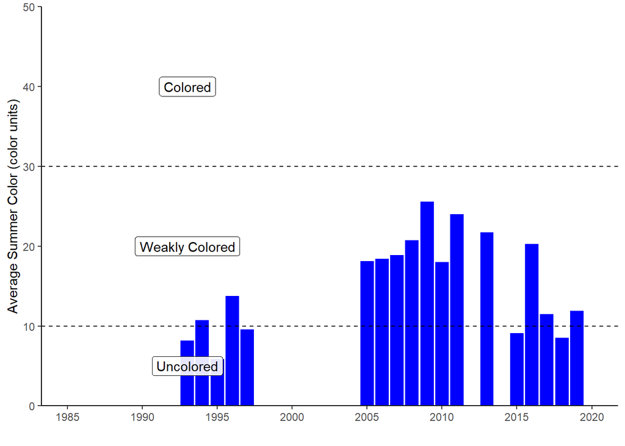

#### Surface and Deep Temperature

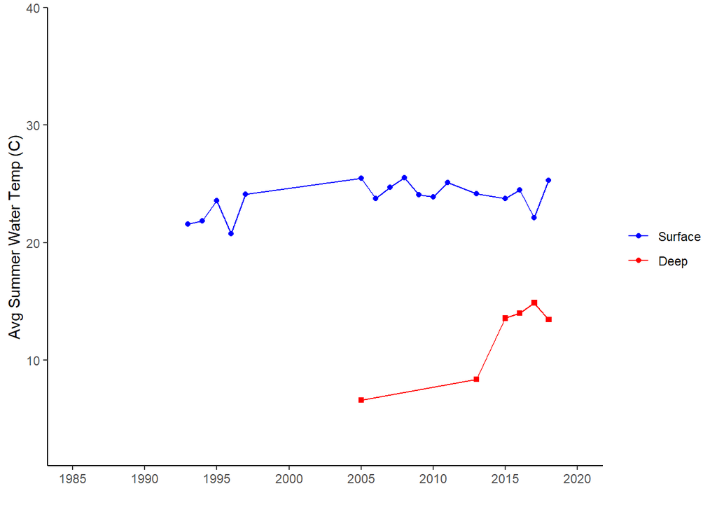

#### Lake Perception

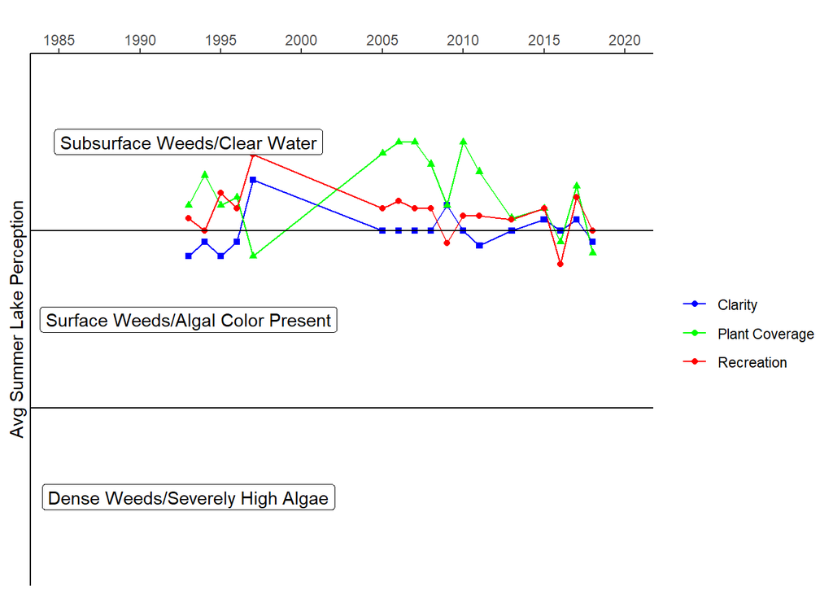